# GYM MEMBER FITNESS DATA: WORKOUT SESSIONS, CALORIC EXPENDITURE, AND BODY COMPOSITION

```python
import pandas as pd
```

```python
df=pd.read_csv(r"gym_members_exercise_tracking.csv")
```

## How does BMI correlate with workout type preference and session duration?

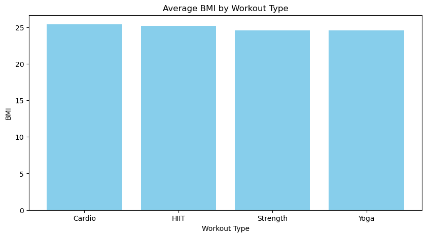

```python
import pandas as pd
import matplotlib.pyplot as plt

df = pd.read_csv(r'gym_members_exercise_tracking.csv')

# Group by Workout_Type and calculate averages
bmi_session = df.groupby('Workout_Type').agg({'BMI': 'mean', 'Session_Duration (hours)': 'mean'}).reset_index()

# Bar chart for BMI by workout type
plt.figure(figsize=(10, 5))
plt.bar(bmi_session['Workout_Type'], bmi_session['BMI'], color='skyblue')
plt.title('Average BMI by Workout Type')
plt.xlabel('Workout Type')
plt.ylabel('BMI')
plt.savefig("Average BMI by Workout Type.png")
plt.show()
```

## Is there a relationship between resting heart rate (Resting_BPM) and workout frequency or experience level?

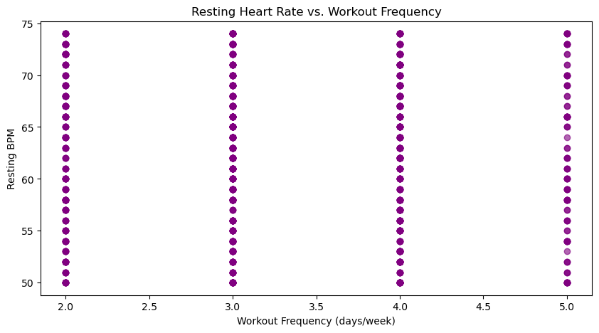

```python
# Scatter plot: Resting_BPM vs. Workout_Frequency
plt.figure(figsize=(10, 5))
plt.scatter(df['Workout_Frequency (days/week)'], df['Resting_BPM'], alpha=0.6, color='purple')
plt.title('Resting Heart Rate vs. Workout Frequency')
plt.xlabel('Workout Frequency (days/week)')
plt.ylabel('Resting BPM')
plt.savefig("Resting Heart Rate vs. Workout Frequency.png")
plt.show()
```

## Do individuals with higher fat percentages burn calories at a different rate during specific workout types (e.g., HIIT vs. Yoga)?

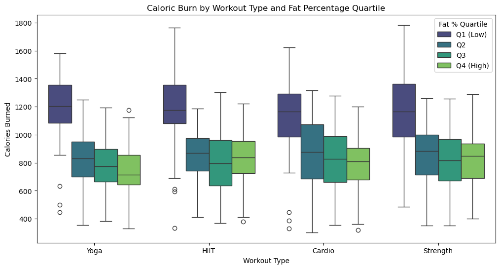

```python
# Question 3: Fat Percentage vs. Caloric Burn by Workout Type
import pandas as pd
import matplotlib.pyplot as plt
import seaborn as sns  # <-- Add this import

df = pd.read_csv(r'gym_members_exercise_tracking.csv')

# Categorize fat percentage into quartiles
df['Fat_Quartile'] = pd.qcut(df['Fat_Percentage'], q=4, labels=['Q1 (Low)', 'Q2', 'Q3', 'Q4 (High)'])

# Boxplot by workout type and fat quartile
plt.figure(figsize=(12, 6))
sns.boxplot(x='Workout_Type', y='Calories_Burned', hue='Fat_Quartile', data=df, palette='viridis')
plt.title('Caloric Burn by Workout Type and Fat Percentage Quartile')
plt.xlabel('Workout Type')
plt.ylabel('Calories Burned')
plt.legend(title='Fat % Quartile')
plt.savefig("Caloric Burn by Workout Type and Fat Percentage Quartile.png")
plt.show()
```

## How do age and gender influence the choice of workout type (e.g., Strength, Cardio, HIIT, Yoga)?

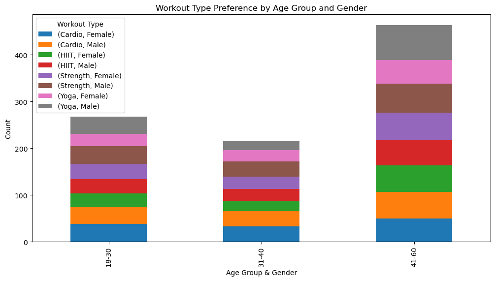

```python
# Create age groups
df['Age_Group'] = pd.cut(df['Age'], bins=[18, 30, 40, 60], labels=['18-30', '31-40', '41-60'])

# Cross-tabulate Age Group, Gender, and Workout_Type
workout_dist = pd.crosstab(index=[df['Age_Group'], df['Gender']], columns=df['Workout_Type'])

# Plot stacked bar chart
workout_dist.unstack().plot(kind='bar', stacked=True, figsize=(12, 6))
plt.title('Workout Type Preference by Age Group and Gender')
plt.xlabel('Age Group & Gender')
plt.ylabel('Count')
plt.legend(title='Workout Type')
plt.savefig("Workout Type Preference by Age Group and Gender.png")
plt.show()
```

## Are there significant differences in average calories burned between male and female participants for the same workout type?

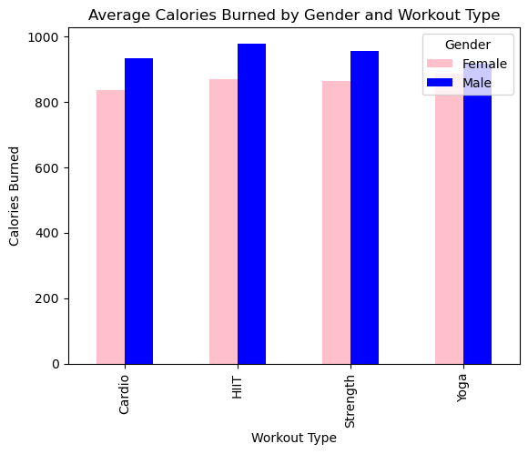

```python
# Grouped bar chart
gender_calories = df.groupby(['Workout_Type', 'Gender'])['Calories_Burned'].mean().unstack()

plt.figure(figsize=(10, 5))
gender_calories.plot(kind='bar', color=['pink', 'blue'])
plt.title('Average Calories Burned by Gender and Workout Type')
plt.xlabel('Workout Type')
plt.ylabel('Calories Burned')
plt.legend(title='Gender')
plt.savefig("Average Calories Burned by Gender and Workout Type.png")
plt.show()
```

## Does water intake (liters/day) vary by gender or age group, and does it correlate with session duration or intensity?

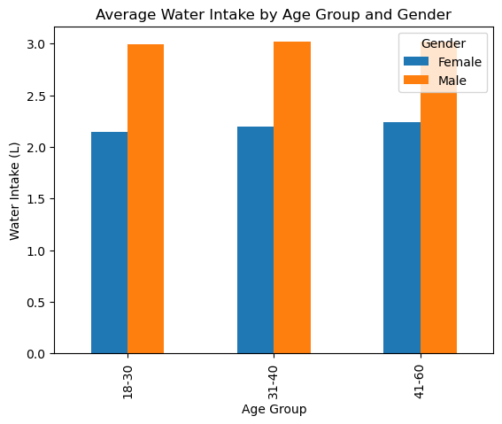

```python
# Bar chart: Water intake by gender and age group
water_age_gender = df.groupby(['Age_Group', 'Gender'],observed=True)['Water_Intake (liters)'].mean().unstack()

plt.figure(figsize=(10, 5))
water_age_gender.plot(kind='bar')
plt.title('Average Water Intake by Age Group and Gender')
plt.xlabel('Age Group')
plt.ylabel('Water Intake (L)')
plt.legend(title='Gender')
plt.savefig("Average Water Intake by Age Group and Gender.png")
plt.show()
```

## Which workout type yields the highest calorie burn per hour, adjusting for weight and BMI?

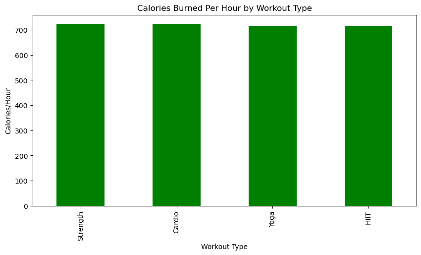

```python
# Calculate calories/hour
df['Calories_Per_Hour'] = df['Calories_Burned'] / df['Session_Duration (hours)']
cal_per_hour = df.groupby('Workout_Type')['Calories_Per_Hour'].mean().sort_values(ascending=False)

# Plot
plt.figure(figsize=(10, 5))
cal_per_hour.plot(kind='bar', color='green')
plt.title('Calories Burned Per Hour by Workout Type')
plt.xlabel('Workout Type')
plt.ylabel('Calories/Hour')
plt.savefig("Calories Burned Per Hour by Workout Type.png")
plt.show()
```

## How does workout frequency (days/week) relate to improvements in fat percentage or BMI over time?

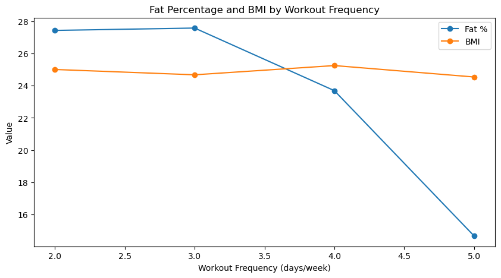

```python
# Aggregate data
freq_fat_bmi = df.groupby('Workout_Frequency (days/week)').agg({'Fat_Percentage': 'mean', 'BMI': 'mean'})

# Line chart
plt.figure(figsize=(10, 5))
plt.plot(freq_fat_bmi.index, freq_fat_bmi['Fat_Percentage'], marker='o', label='Fat %')
plt.plot(freq_fat_bmi.index, freq_fat_bmi['BMI'], marker='o', label='BMI')
plt.title('Fat Percentage and BMI by Workout Frequency')
plt.xlabel('Workout Frequency (days/week)')
plt.ylabel('Value')
plt.legend()
plt.savefig("Fat Percentage and BMI by Workout Frequency.png")
plt.show()
```

## Is there a threshold for session duration (hours) beyond which average heart rate (Avg_BPM) plateaus?

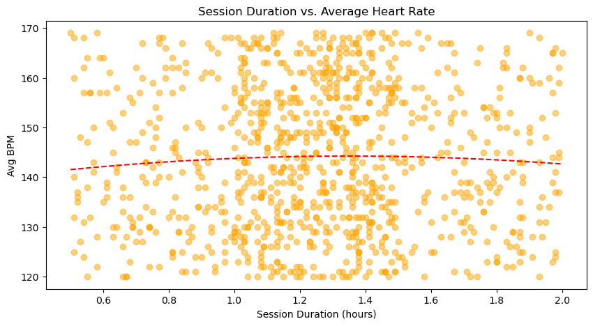

```python
# Add a polynomial trendline
import numpy as np

plt.figure(figsize=(10, 5))
plt.scatter(df['Session_Duration (hours)'], df['Avg_BPM'], alpha=0.5, color='orange')
z = np.polyfit(df['Session_Duration (hours)'], df['Avg_BPM'], 2)
p = np.poly1d(z)
plt.plot(np.sort(df['Session_Duration (hours)']), p(np.sort(df['Session_Duration (hours)'])), 'r--')
plt.title('Session Duration vs. Average Heart Rate')
plt.xlabel('Session Duration (hours)')
plt.ylabel('Avg BPM')
plt.savefig("Session Duration vs. Average Heart Rate.png")
plt.show()
```

## Do participants with higher Max_BPM values exhibit greater caloric expenditure, even after controlling for age and weight?

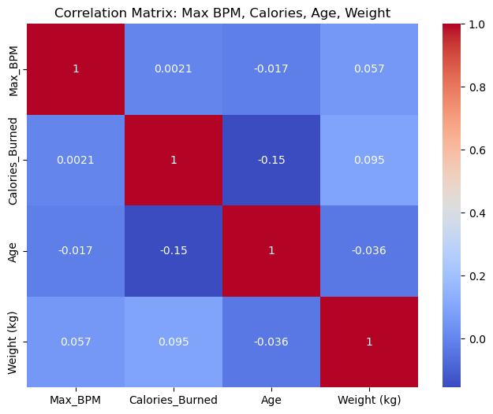

```python
# Calculate correlations
corr_matrix = df[['Max_BPM', 'Calories_Burned', 'Age', 'Weight (kg)']].corr()

# Heatmap
plt.figure(figsize=(8, 6))
sns.heatmap(corr_matrix, annot=True, cmap='coolwarm')
plt.title('Correlation Matrix: Max BPM, Calories, Age, Weight')
plt.savefig("Correlation Matrix: Max BPM, Calories, Age, Weight.png")
plt.show()
```

## How does resting heart rate (Resting_BPM) correlate with cardiovascular-focused workouts (e.g., Cardio, HIIT)?

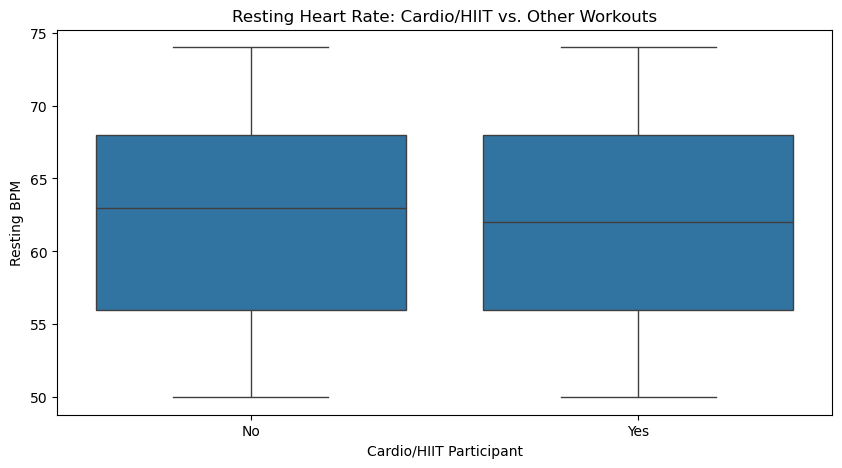

```python
# Create cardio-focused flag
df['Cardio_Focused'] = df['Workout_Type'].isin(['Cardio', 'HIIT'])

# Boxplot
plt.figure(figsize=(10, 5))
sns.boxplot(x='Cardio_Focused', y='Resting_BPM', data=df)
plt.title('Resting Heart Rate: Cardio/HIIT vs. Other Workouts')
plt.xlabel('Cardio/HIIT Participant')
plt.ylabel('Resting BPM')
plt.xticks([0, 1], ['No', 'Yes'])
plt.savefig("Resting Heart Rate.png")
plt.show()
```

## Are there differences in BMI or fat percentage between participants who prioritize Strength training versus Cardio?

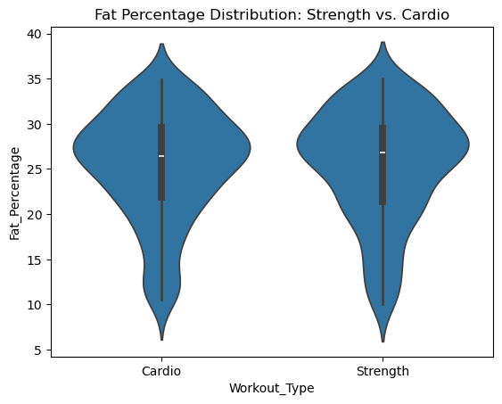

```python
# Filter data
strength_cardio = df[df['Workout_Type'].isin(['Strength', 'Cardio'])]
# Violin plot for fat %
sns.violinplot(x='Workout_Type', y='Fat_Percentage', data=strength_cardio)
plt.title('Fat Percentage Distribution: Strength vs. Cardio')
plt.savefig("Fat Percentage Distribution.png")
plt.show()
```

## Does experience level predict adherence to workout frequency or session duration?

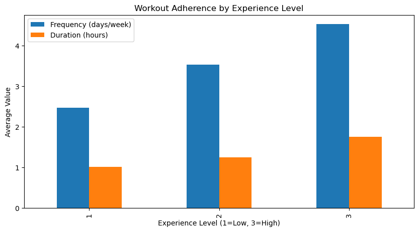

```python
# Grouped bar chart
experience_adherence = df.groupby('Experience_Level').agg({'Workout_Frequency (days/week)': 'mean', 'Session_Duration (hours)': 'mean'})

experience_adherence.plot(kind='bar', figsize=(10, 5))
plt.title('Workout Adherence by Experience Level')
plt.xlabel('Experience Level (1=Low, 3=High)')
plt.ylabel('Average Value')
plt.legend(['Frequency (days/week)', 'Duration (hours)'])
plt.savefig("Workout Adherence by Experience Level.png")
plt.show()
```

## How does water intake influence workout performance metrics (e.g., Avg_BPM, calories burned)?

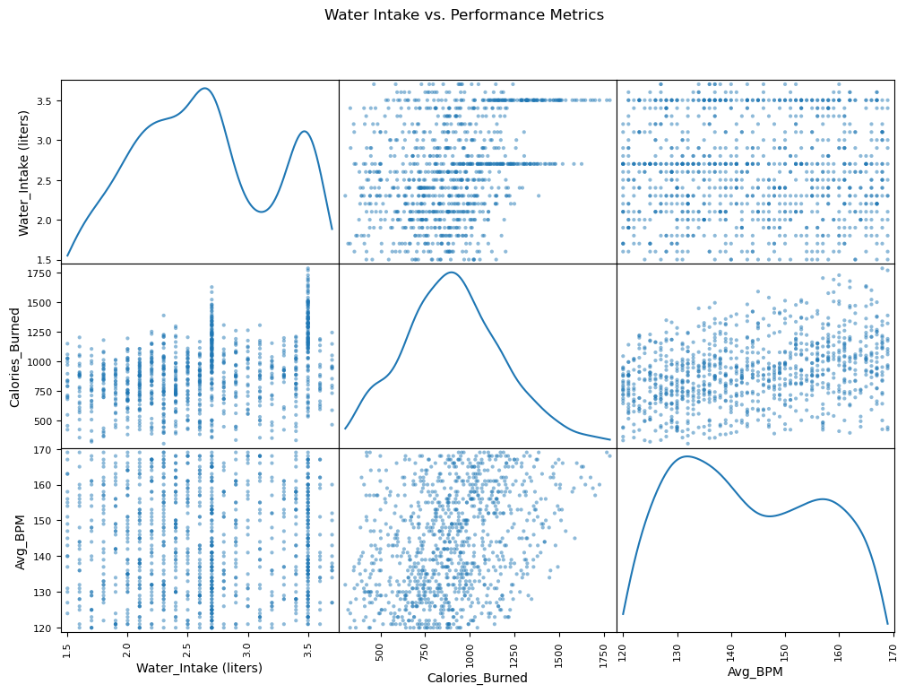

```python
# Scatter matrix
from pandas.plotting import scatter_matrix

scatter_matrix(df[['Water_Intake (liters)', 'Calories_Burned', 'Avg_BPM']], figsize=(12, 8), diagonal='kde')
plt.suptitle('Water Intake vs. Performance Metrics')
plt.savefig("Water Intake vs. Performance Metrics.png")
plt.show()
```

## Can workout type and frequency be clustered to identify distinct member profiles for personalized training recommendations?

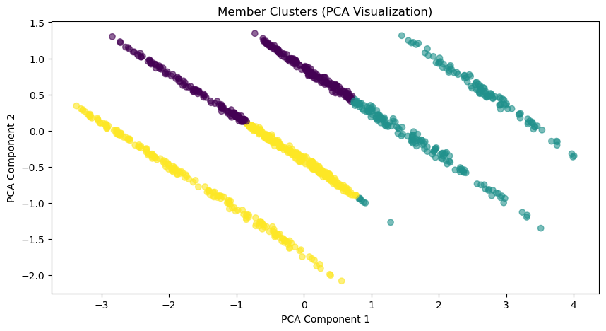

```python
# Clustering (example with k-means)
from sklearn.cluster import KMeans
from sklearn.preprocessing import StandardScaler

# Preprocess data
X = df[['Workout_Frequency (days/week)', 'Session_Duration (hours)', 'Calories_Burned']]
X = StandardScaler().fit_transform(X)

# K-means clustering
kmeans = KMeans(n_clusters=3)
df['Cluster'] = kmeans.fit_predict(X)

# PCA for visualization
from sklearn.decomposition import PCA

pca = PCA(n_components=2)
X_pca = pca.fit_transform(X)

# Plot
plt.figure(figsize=(10, 5))
plt.scatter(X_pca[:, 0], X_pca[:, 1], c=df['Cluster'], cmap='viridis', alpha=0.6)
plt.title('Member Clusters (PCA Visualization)')
plt.xlabel('PCA Component 1')
plt.ylabel('PCA Component 2')
plt.savefig("Member Clusters (PCA Visualization).png")
plt.show()
```